# Morphological Analysis : English

Text Mining

Morphological Analysis For English in Text Mining

Yeongeun Jeon  
05-10-2021

- 출처 : [R를 이용한 텍스트 마이닝](http://www.kyobobook.co.kr/product/detailViewKor.laf?mallGb=KOR&ejkGb=KOR&barcode=9788946072190)

> **Contents**
- 문장단위 주석 처리
- 단어단위 주석 처리
- 품사분석
  - 품사 Tagging된 단어 추출
- Corpus에 대한 품사분석

> 문장을 구성하는 `단어는 고유한 문법적 기능`을 수행하며, `문법적 성질의 공통성`에 따라 몇 갈래로 묶어 놓은 것을 `품사`라고 한다. 예를 들어, `대명사`, `명사`, `동사`, `형용사`, `부사` 등이 있다. 이렇게 단어에 품사를 붙여주는 작업을 품사분석(Part-Of-Speech), POS분석이라고 한다.

> 영어에서는 텍스트 객체에 대해 먼저 `문장 단위 주석작업`을 실시한 후, 해당문장에서 `각 단어가 어떤 문법적 기능`을 수행하는지 품사분석을 실시한다. 예시로 R을 소개하는 위키피디아 두 문단의 텍스트에 대해 POS분석을 실시해보았다.

```
pacman::p_load("NLP", "openNLP",
               "tm", "stringr")

R.wiki <- "R is a programming language and software environment for statistical computing and graphics supported by the R Foundation for Statistical Computing.
           The R language is widely used among statisticians and data miners for developing statistical software and data analysis.
           Polls, surveys of data miners, and studies of scholarly literature databases show that R's popularity has increased substantially in recent years.
           R is a GNU package.
           The source code for the R software environment is written primarily in C, Fortran, and R.
           R is freely available under the GNU General Public License, and pre-compiled binary versions are provided for various operating systems.
           While R has a command line interface, there are several graphical front-ends available."
```

# **문장단위 주석 처리**

```r
annotate(test object, Maxent_Sent_Token_Annotator())
```

- `annotate` : 주석 작업
- `Maxent_Sent_Token_Annotator()` : 문장 단위의 주석작업 실시

[output not shown]

```
 id type     start end features
  1 sentence     1 148
  2 sentence   162 281
  3 sentence   295 440
  4 sentence   453 471
  5 sentence   485 722
  6 sentence   736 822
```

- 6번째 문장은 736번째에서 시작하여 822번째에서 종료됨

# **단어단위 주석 처리**

```
annotate(object, Maxent_Word_Token_Annotator(), sent.result)
```

- `Maxent_Word_Token_Annotator()` : 단어 단위의 주석작업 실시
- `sent.result` : 문장 단위가 어떻게 주석작업 되었는지 나타내는 변수로, `Maxent_Sent_Token_Annotator()`의 결과

[output not shown]

```
 id  type     start end features
   1 sentence     1 148 constituents=<<integer,22>>
   2 sentence   162 281 constituents=<<integer,19>>
   3 sentence   295 440 constituents=<<integer,25>>
   4 sentence   453 471 constituents=<<integer,6>>
   5 sentence   485 722 constituents=<<integer,40>>
   6 sentence   736 822 constituents=<<integer,15>>
   7 word         1   1
   8 word         3   4
   9 word         6   6
  10 word         8  18
  11 word        20  27
  12 word        29  31
  13 word        33  40
  14 word        42  52
```

[output cut: 119 more lines]

- 1번째 줄부터 6번째 줄까지는 문장에 대한 주석작업 결과
- 일곱번째부터 단어에 대한 주석작업 결과
  - 1번째 문장은 1번째에서 시작해서 148번째에 종료함으로 7번째 줄부터 28번째 줄까지의 단어를 포함
    - 7번째 줄은 1번째 문장의 1번째 단어로 1개로 이루어진 단어
    - 8번째 줄은 1번째 문장의 2번째 단어로 2개로 이루어진 단어

# **품사분석**

```
annotate(object, Maxent_POS_Tag_Annotator(), word.result)
```

- `Maxent_POS_Tag_Annotator()` : 품사분석 실시
- `word.result` : 단어 단위가 어떻게 주석작업 되었는지 나타내는 변수로, `Maxent_Word_Token_Annotator()`의 결과

```
POStag <- annotate(R.wiki, Maxent_POS_Tag_Annotator(), R.wiki.word)  # Maxent_POS_Tag_Annotator : 품사분석석
POStag
```

```
 id  type     start end features
   1 sentence     1 148 constituents=<<integer,22>>
   2 sentence   162 281 constituents=<<integer,19>>
   3 sentence   295 440 constituents=<<integer,25>>
   4 sentence   453 471 constituents=<<integer,6>>
   5 sentence   485 722 constituents=<<integer,40>>
   6 sentence   736 822 constituents=<<integer,15>>
   7 word         1   1 POS=NN
   8 word         3   4 POS=VBZ
   9 word         6   6 POS=DT
  10 word         8  18 POS=NN
  11 word        20  27 POS=NN
  12 word        29  31 POS=CC
  13 word        33  40 POS=NN
  14 word        42  52 POS=NN
```

[output cut: 119 more lines]

- `features`에 품사분석의 결과가 나타남
  - `NN` : 명사
  - `VBZ` : 3인칭 현재형 단수 동사

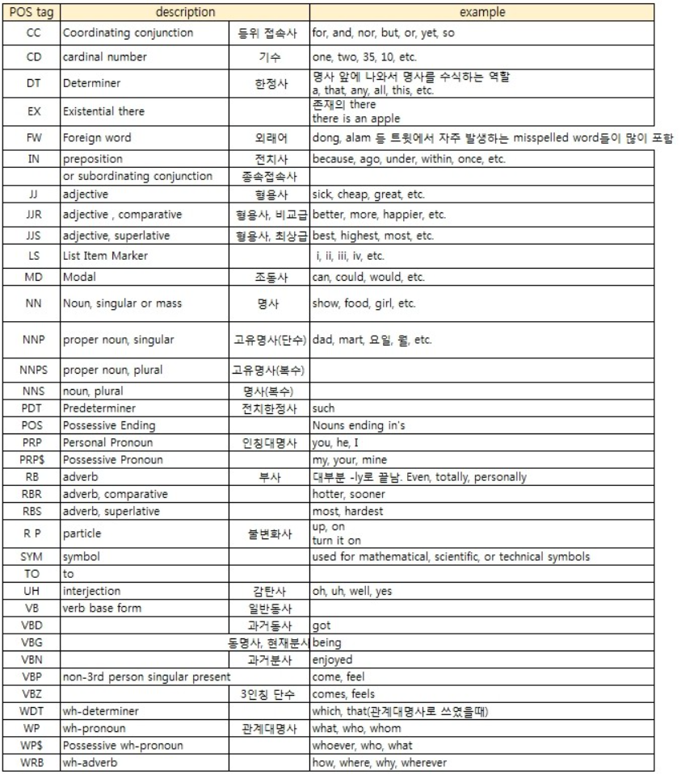

## **품사 Tagging된 단어 추출**

[output not shown]

```
  POS   POS   POS   POS   POS   POS   POS   POS   POS   POS   POS
 "NN" "VBZ"  "DT"  "NN"  "NN"  "CC"  "NN"  "NN"  "IN"  "JJ"  "NN"
  POS   POS   POS   POS   POS   POS   POS   POS   POS   POS   POS
 "CC" "NNS" "VBN"  "IN"  "DT"  "NN" "NNP"  "IN" "NNP" "NNP"   "."
  POS   POS   POS   POS   POS   POS   POS   POS   POS   POS   POS
 "DT"  "NN"  "NN" "VBZ"  "RB" "VBN"  "IN" "NNS"  "CC" "NNS" "NNS"
  POS   POS   POS   POS   POS   POS   POS   POS   POS   POS   POS
 "IN" "VBG"  "JJ"  "NN"  "CC" "NNS"  "NN"   "." "NNS"   "," "NNS"
  POS   POS   POS   POS   POS   POS   POS   POS   POS   POS   POS
 "IN" "NNS" "NNS"   ","  "CC" "NNS"  "IN"  "JJ"  "NN" "NNS" "VBP"
  POS   POS   POS   POS   POS   POS   POS   POS   POS   POS   POS
 "IN"  "NN" "POS"  "NN" "VBZ" "VBN"  "RB"  "IN"  "JJ" "NNS"   "."
  POS   POS   POS   POS   POS   POS   POS   POS   POS   POS   POS
 "NN" "VBZ"  "DT" "NNP"  "NN"   "."  "DT"  "NN"  "NN"  "IN"  "DT"
  POS   POS   POS   POS   POS   POS   POS   POS   POS   POS   POS
 "NN"  "NN"  "NN" "VBZ" "VBN"  "RB"  "IN" "NNP"   "," "NNP"   ","
  POS   POS   POS   POS   POS   POS   POS   POS   POS   POS   POS
 "CC" "NNP"  "NN" "VBZ"  "RB"  "JJ"  "IN"  "DT" "NNP" "NNP" "NNP"
  POS   POS   POS   POS   POS   POS   POS   POS   POS   POS   POS
"NNP"   ","  "CC"  "JJ"  "JJ" "NNS" "VBP" "VBN"  "IN"  "JJ" "VBG"
  POS   POS   POS   POS   POS   POS   POS   POS   POS   POS   POS
"NNS"   "."  "IN"  "NN" "VBZ"  "DT"  "NN"  "NN"  "NN"   ","  "EX"
  POS   POS   POS   POS   POS   POS
"VBP"  "JJ"  "JJ" "NNS"  "JJ"   "."
```

### **Tag의 빈도**

```
table(all.POS.tagged)
```

```
all.POS.tagged
  ,   .  CC  DT  EX  IN  JJ  NN NNP NNS POS  RB VBG VBN VBP VBZ
  6   6   7   8   1  14  11  26  11  15   1   4   2   5   3   7
```

```
sum(table(all.POS.tagged))
```

```
[1] 127
```

### **문장부호 갯수**

```
my.PUNCT <- str_detect(all.POS.tagged,'[[:punct:]]') # 문장부호 갯수수
sum(my.PUNCT)
```

```
[1] 12
```

### **NN Tag 갯수**

```
my.NN <- str_detect(all.POS.tagged,"NN$") # NN tag 갯수수
sum(my.NN)
```

```
[1] 26
```

### **NN으로 시작하는 모든 Tag 갯수**

[output not shown]

```
[1] 52
```

# **Corpus에 대한 품사분석**

```
# 품사분석에 대한 함수
my.POStag.func <- function(mytext){
  sent.annotate <- annotate(mytext,Maxent_Sent_Token_Annotator())                 # 문장 Tag
  word.annotate <- annotate(mytext,Maxent_Word_Token_Annotator(),sent.annotate)   # 단어 Tag
  POStag <- annotate(mytext,Maxent_POS_Tag_Annotator(),word.annotate)             # 품사 분석석
  myrange <- (1 + length(sent.annotate)):length(word.annotate)
  my.POStag <- unlist(POStag$features[myrange])
  my.POStag
}


mytext <- c("The sky is blue. Therefore, I feel happy.",
            "The sun is bright today. My feeling is good.",
            "The sun in the sky is bright. The sky is blue.",
            "We can see the shining sun, the bright sun. The weather is nice today.")

corpus <- VCorpus(VectorSource(mytext))     # VectorSource : vector를 document로 해석석


mypaper1.POStag <- my.POStag.func(corpus[[1]]$content)  # 첫번째 Corpus에 대한 품사 분석
mypaper1.POStag
```

```
  POS   POS   POS   POS   POS   POS   POS   POS   POS   POS   POS
 "DT"  "NN" "VBZ"  "JJ"   "."  "RB"   "," "PRP" "VBP"  "JJ"   "."
```

```
sum(str_detect(mypaper1.POStag,"NN")) # 명사+대명사 개수수
```

```
[1] 1
```

[output not shown]

```
[1] 0.09 0.27 0.23 0.24
```

[output not shown]

```
  abstract.no  prop.noun
1           1 0.09090909
```

```
tail(prop.noun[order(prop.noun$prop.noun),],1)
```

```
  abstract.no prop.noun
2           2 0.2727273
```